# R Notebook

# Data Visualisation 1 - Relative Freqeucny Histogram

## Why relative frequqncy?

Our hypothesis deals with finding out whether there exists a difference in the usage of upper class terms and lower class terms within a corpus of science fiction novels as comapred to non science fiction novels.

```r
library(ggthemes)
library(dplyr)
library(ggplot2)
```

The simplest way to understand the difference in usage of these terms is to just calculate the relative frequency in which these terms are occurring within a particular novel. Relative frequency gives us a solid idea about the difference in usage of these terms in terms of the relative quantity in which these terms occur throughout our corpus.

```r
all_authors_frequency <- all_authors_tagged %>%
  group_by(title) %>%
  add_count(name = "length") %>%
  mutate(upper_class_count = sum(upper_class , na.rm = TRUE)) %>%
  mutate(rfreqUC = upper_class_count / length) %>%
  mutate(lower_class_count = sum(lower_class , na.rm = TRUE)) %>%
  mutate(rfreqLC = lower_class_count / length) %>%
  select(genre , author , title , rfreqUC , rfreqLC) %>%
  distinct()
```

The value of the relative frequency of these terms is a continuous variable and so a histogram has been used to graphically represent the relative usage of these terms. The x axis of the histogram denotes the value of rwelative frequqncy of the usage of a particular term group and the y axis indicates the count or the number of novels in which that relative frequency value occurs.

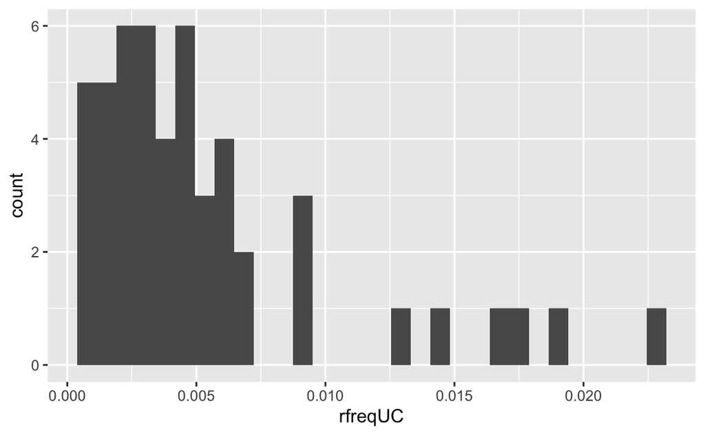

```r
all_authors_frequency %>%
  ggplot(aes(rfreqUC)) +
  geom_histogram()
```

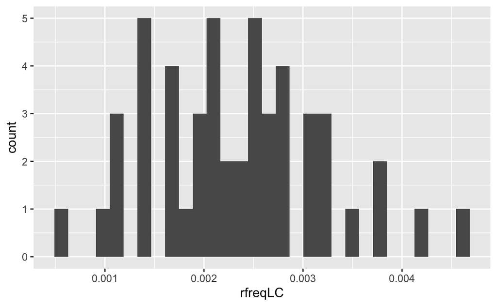

```r
all_authors_frequency %>%
  ggplot(aes(rfreqLC)) +
  geom_histogram()
```